# The Abstract and the Argument

Types of Abstracts, Definitions, Hypotheses, DV and IV

Bogdan G. Popescu

bogdan.popescu@johncabot.edu

John Cabot University

## Abstract

The **abstract** is an invitation to the reader to keep reading. It is a roadmap for the article.

It gives readers a preview of what it is to come.

It also showcases the unique contribution

## Abstract

### Timing

Writing the abstract is an iterative process:

- you should start with an abstract
- you should rewrite the abstract at the end as you write/progress the research

You should start by looking at three examples of abstracts from three selected articles.

It is usually one paragraph (100-250 words)

## Abstract

### Structure

The basic structure entails:

- broad statement: your thesis
- move towards your specific topic
- method
- finding/results
- discussion of the wider implication(s) of your finding

## Abstract

### Types

1 **Puzzle**

“Country A and country B are similar. Yet phenomenon X only happens in country A, but not B, why is that?”

2 **Critique/Summary**

“Some scholars looked at problem X pertaining to the big topic A. Other scholars looked at problem Y pertaining to the big topic A. Yet, nobody examined problem Z pertaining to the big topic A. Problem Z is important because”

3 **Study/Finding**

“This article analyzes/documents…”

## Abstract

### To Do

Gender quotas traditionally focus on the underrepresentation of women. Conceiving of quotas in this way perpetuates the status of men as the norm and women as the “other.” Women are subject to heavy scrutiny of their qualifications and competence, whereas men’s credentials go unchallenged. This article calls for a normative shift in the problem of overrepresentation, arguing that the quality of representation is negatively affected by having too large a group drawn from too narrow a talent pool. Curbing overrepresentation through ceiling quotas for men offers three core benefits. First, it promotes meritocracy by ensuring the proper scrutiny of politicians of both sexes. Second, it provides an impetus for improving the criteria used to select and evaluate politicians. Third, neutralizing the overly masculinized environment within parliaments might facilitate better substantive and symbolic representation of both men and women. All citizens would benefit from these measures to increase the quality of representation.

## Abstract

### To Do

Gender quotas traditionally focus on the underrepresentation of women. Conceiving of quotas in this way perpetuates the status of men as the norm and women as the “other.” Women are subject to heavy scrutiny of their qualifications and competence, whereas men’s credentials go unchallenged. This article calls for a normative shift in the problem of overrepresentation, arguing that the quality of representation is negatively affected by having too large a group drawn from too narrow a talent pool. Curbing overrepresentation through ceiling quotas for men offers three core benefits. First, it promotes meritocracy by ensuring the proper scrutiny of politicians of both sexes. Second, it provides an impetus for improving the criteria used to select and evaluate politicians. Third, neutralizing the overly masculinized environment within parliaments might facilitate better substantive and symbolic representation of both men and women. All citizens would benefit from these measures to increase the quality of representation.

**Broad statement: your thesis**

*“Gender quotas traditionally focus on the underrepresentation of women. Conceiving of quotas in this way perpetuates the status of men as the norm and women as the “other.”*

This opening frames the broader critique: the traditional framing of gender quotas reinforces gender hierarchy.

## Abstract

### To Do

Gender quotas traditionally focus on the underrepresentation of women. Conceiving of quotas in this way perpetuates the status of men as the norm and women as the “other.” Women are subject to heavy scrutiny of their qualifications and competence, whereas men’s credentials go unchallenged. This article calls for a normative shift in the problem of overrepresentation, arguing that the quality of representation is negatively affected by having too large a group drawn from too narrow a talent pool. Curbing overrepresentation through ceiling quotas for men offers three core benefits. First, it promotes meritocracy by ensuring the proper scrutiny of politicians of both sexes. Second, it provides an impetus for improving the criteria used to select and evaluate politicians. Third, neutralizing the overly masculinized environment within parliaments might facilitate better substantive and symbolic representation of both men and women. All citizens would benefit from these measures to increase the quality of representation.

**Move towards your specific topic**

*“This article calls for a normative shift in the problem of overrepresentation, arguing that the quality of representation is negatively affected by having too large a group drawn from too narrow a talent pool.”*

This introduces the specific intervention: focusing on male overrepresentation rather than just female underrepresentation.

## Abstract

### To Do

Gender quotas traditionally focus on the underrepresentation of women. Conceiving of quotas in this way perpetuates the status of men as the norm and women as the “other.” Women are subject to heavy scrutiny of their qualifications and competence, whereas men’s credentials go unchallenged. This article calls for a normative shift in the problem of overrepresentation, arguing that the quality of representation is negatively affected by having too large a group drawn from too narrow a talent pool. Curbing overrepresentation through ceiling quotas for men offers three core benefits. First, it promotes meritocracy by ensuring the proper scrutiny of politicians of both sexes. Second, it provides an impetus for improving the criteria used to select and evaluate politicians. Third, neutralizing the overly masculinized environment within parliaments might facilitate better substantive and symbolic representation of both men and women. All citizens would benefit from these measures to increase the quality of representation.

**Method**

*Not explicitly stated in the abstract.*

## Abstract

### To Do

Gender quotas traditionally focus on the underrepresentation of women. Conceiving of quotas in this way perpetuates the status of men as the norm and women as the “other.” Women are subject to heavy scrutiny of their qualifications and competence, whereas men’s credentials go unchallenged. This article calls for a normative shift in the problem of overrepresentation, arguing that the quality of representation is negatively affected by having too large a group drawn from too narrow a talent pool. Curbing overrepresentation through ceiling quotas for men offers three core benefits. First, it promotes meritocracy by ensuring the proper scrutiny of politicians of both sexes. Second, it provides an impetus for improving the criteria used to select and evaluate politicians. Third, neutralizing the overly masculinized environment within parliaments might facilitate better substantive and symbolic representation of both men and women. All citizens would benefit from these measures to increase the quality of representation.

**Finding/results**

*“Curbing overrepresentation through ceiling quotas for men offers three core benefits. First, it promotes meritocracy […] Second, it provides an impetus for improving the criteria […] Third, neutralizing the overly masculinized environment […]”*

These are the core normative or conceptual “results” of the argument.

## Abstract

### To Do

Gender quotas traditionally focus on the underrepresentation of women. Conceiving of quotas in this way perpetuates the status of men as the norm and women as the “other.” Women are subject to heavy scrutiny of their qualifications and competence, whereas men’s credentials go unchallenged. This article calls for a normative shift in the problem of overrepresentation, arguing that the quality of representation is negatively affected by having too large a group drawn from too narrow a talent pool. Curbing overrepresentation through ceiling quotas for men offers three core benefits. First, it promotes meritocracy by ensuring the proper scrutiny of politicians of both sexes. Second, it provides an impetus for improving the criteria used to select and evaluate politicians. Third, neutralizing the overly masculinized environment within parliaments might facilitate better substantive and symbolic representation of both men and women. All citizens would benefit from these measures to increase the quality of representation.

**Discussion of the wider implication(s) of your finding**

*“All citizens would benefit from these measures to increase the quality of representation.”*

This generalizes the argument, highlighting democratic and societal benefits for everyone—not just women.

## Abstract

### To Do

Spend 10 minutes with the 3 articles and identify:

- broad statement: your thesis
- move towards your specific topic
- method
- finding/results
- discussion of the wider implication(s) of your finding

## Abstract

### Homework

Produce an abstract of 300 words following the formula discussed.

## Abstract

### Conclusion

The abstract should end by revisiting the puzzle or the critique - the most important takeaway of your analysis and argument.

It should also place it in a broader context and why the research matters.

- it could solve a long-standing puzzle/argument in the literature
- it could intervene in the literature in an important way

You should have a first iteration of this and the rewrite it multiple times as you advance your paper.

- this will become clearer and clearer as you keep rewriting

## Introduction

Many articles have a so-called “argument” or a “theoretical framework.”

This not so set in stone, but the argument typically addresses some of these questions?

1. What factors or variables of the problem must be investigated in order to answer your central question?
2. How are those variable defined? What is their conceptual vs. operational definition?
3. What are your hypotheses (expectations)?
4. What is the spatial/temporal domain of the study?

Similar to all the other elements in the article, there will be some back and forth as you write the article

## Definitions

### Conceptual vs. Operational

Conceptual clarity is crucial for theory-building, while operational definitions are essential for empirical testing and data collection.

**Conceptual Definition** - abstract, theoretical meaning of a concept — what the concept means in principle  
**Example**:  
“Democracy is a system of government in which power is vested in the people”.

**Operational Definition** - how the concept will be measured or observed in practice  
**Example**:  
“Democracy is defined as a country scoring above 7 on the Polity IV scale”.

## Argument

### Intro

An argument is supposed to make sense of the world by indicating the factors that contribute to the outcome

Thus, a theory is *parsimonious*: tries to explain as much as possible with as little as possible

- it minimizes the number of factors to be treated as analytically relevant to the outcome.

A theory is also *generalizable*: can be applied to a variety of contexts

## Argument

### Intro

**Empirical theory**: describes what is using data

Example:

“Young voters aged 18–24 have the lowest voter turnout rate in national elections, based on data from the last five election cycles.”

**Normative theory**: explores what ought to be

Example:

“Young people **ought** to vote more because they have a moral responsibility to shape the future of their democracy.”

## Hypotheses

Hypotheses clearly specified expectation - putative answer to your reseach question

Hypotheses can be tested with evidence (confirmatory research) or operate as a guide to a process of discovery (exploratory research).

Exploratory research begins with a question and perhaps a basic proposition, probes its plausibility against various types of data.

Hypothese are typically predictive:

- If circumstances X and Y exist, Z is likely to occur or come into being.

Example:

As the number of hours of negative ads watched increases, the probability that an individual will vote decreases.

## DAGs

## Testing Theories

Hypothesis testing uses logical or empirical evidence to evaluate existing theories

## Inductive vs. Deductive Theories

Hypotheses can be tested with evidence (starting from obserations) - inductive research

- the researcher observes a phenomenon and the refines their hypothesis

Hypotheses can be statements that guide a process of discovery (starting with theory) - deductive research

## Inductive vs. Deductive Theories

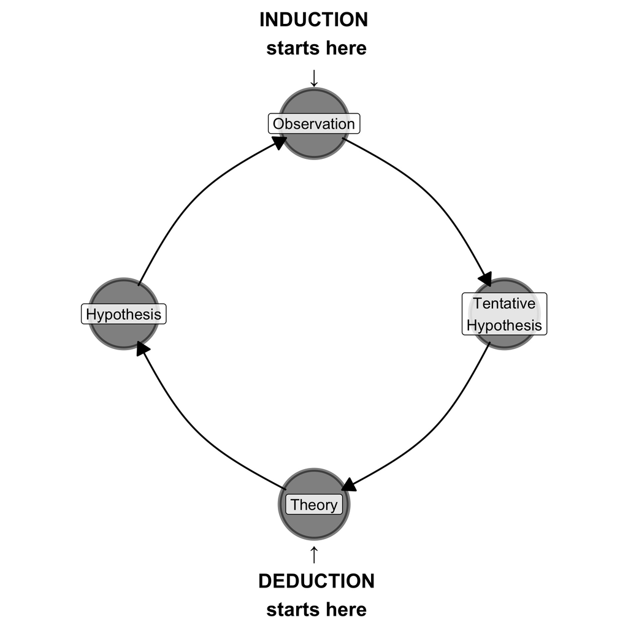

## Components of a Hypothesis

Any hypothesis needs to have:

- DV
- IV

**Dependent Variable** - the variable is what we are trying to explain; usually some political outcome (event or process that)

**Independent Variable** - the variable thought to cause or influence the dependent variable.

**Intervening Variable** - influences the relation between the DV and IV and thus produces an interaction effect

## Components of a Hypothesis

### Examples

What effects do environmental pressures have on conflict within developing countries?

**DV**: likelihood of conflict  
**IV**: environmental pressures (e.g. demographic and environmental stress)

Variables also have values. For example:

**DV**: likelihood of conflict  
**Potential Values**: high or low

**IV**: environmental pressures  
**Potential Values**: high or low

## Relationships

### Correlation

Two variables can *covary* or be *correlated*: positive or negative

**Example Positive Correlation**:

- inflation and unemployment can go up at the same time
- when inflation goes up, so does unemployment

**Example Negative Correlation**:

- inflation and unemployment can go down at the same time
- when inflation goes down, so does unemployment

## Relationships

### Causality

In order for two variables to be causally related three conditions must be met

1. The IV is temporally prior to the DV
2. The IV and DV are correlated or co-vary
3. The IV and DV are not spuriously correlated (i.e. just by coincidence)